# HW2-exploration

Author

Madi Calbert

Published

February 2, 2025

# Set Up

```r
#load libraries
library(tidyverse)
library(here)
library(janitor)
library(scales)

#load data
cites <- read.csv(here("data/cites_felidae_1975_2024.csv"))
cites_recent <- read.csv(here("data/cites_felidae_2000_2024.csv"))
```

# Tidy Data

```r
#clean and wrangle data
cites <- cites %>%
  clean_names()

#add column of common names of top 10 species
common_names <- data.frame(
  taxon = c("Panthera leo",
            "Panthera tigris",
            "Acinonyx jubatus",
            "Panthera pardus",
            "Lynx rufus",
            "Puma concolor",
            "Lynx lynx",
            "Leptailurus serval",
            "Caracal caracal",
            "Lynx canadensis"),
  common_name = c("Lion",
                  "Tiger",
                  "Cheetah",
                  "Leopard",
                  "Bobcat",
                  "Mountain Lion",
                  "Eurasian Lynx",
                  "Serval",
                  "Caracal",
                  "Canada Lynx"))

cites <- cites %>%
  left_join(common_names, by = "taxon")

missing_species <- cites %>%
  filter(is.na(common_name)) %>%
  distinct(taxon)

# print(missing_species)  #shows scientific names without a match, there's a lot lol
```

# Data Exploration

## Top 10 Reported Species

What is the most commonly reported species from the *Felidae* Family in the CITES database?

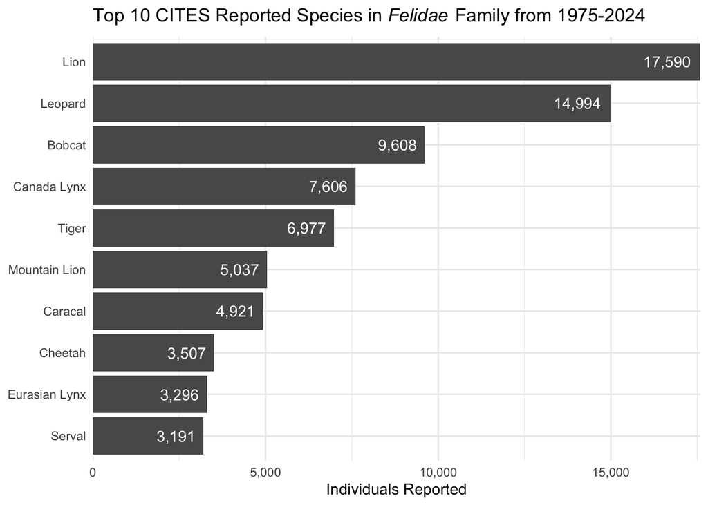

```r
#data viz of most commonly reported species

#Count instances per Taxon
species_count <- cites %>%
  count(taxon)

#Merge counts and common names
top_species <- species_count %>%
  left_join(common_names, by = "taxon")

#Arrange and select top 10 species
top_species <- top_species %>%
  arrange(n) %>%
  slice_max(n, n = 10)

#Plot top 10 species
ggplot(top_species, aes(x = reorder(common_name, n), y = n)) +
  geom_col() +
  geom_text(aes(label = comma(n)), hjust = 1.2, color = "white") +
  coord_flip() +
  theme_minimal() +
  labs(y = "Individuals Reported",
       x = NULL,
       title = expression("Top 10 CITES Reported Species in " * italic("Felidae") * " Family from 1975-2024")) +
   scale_y_continuous(expand = expansion(mult = c(0,0)), labels = comma)
```

## Importers / Exporters

Which countries are the largest importers/exporters for the top 10 species within the *Felidae* Family?

```r
#create new df to isolate the top 10 reported species from above
top_cats_2024 <- cites %>%
  filter(common_name %in% top_species$common_name) %>%
  filter(year == 2024)

top_cats <- cites %>%
  filter(common_name %in% top_species$common_name)

#I want to try to make a map that shows the flows of exporting countries to importing countries
```

```r
# amount of live lions in the database, just was curious
cites %>%
  filter(common_name == "Lion") %>%
  filter(term == "live") %>%
  count(taxon)
```

```
         taxon    n
1 Panthera leo 3663
```

## Purpose / Source

What is the most common purpose (captive breeding, hunting, circus, etc.) for top 10 cat transactions?

The reported purpose of the transaction is shown as a one-letter code:

- B Breeding in captivity or artificial propagation
- E Educational
- G Botanical garden
- H Hunting trophy
- L Law enforcement/judicial/forensic
- M Medical (including biomedical research)
- N Reintroduction or introduction into the wild
- P Personal
- Q Circus or travelling exhibition
- S Scientific
- T Commercial
- Z Zoo

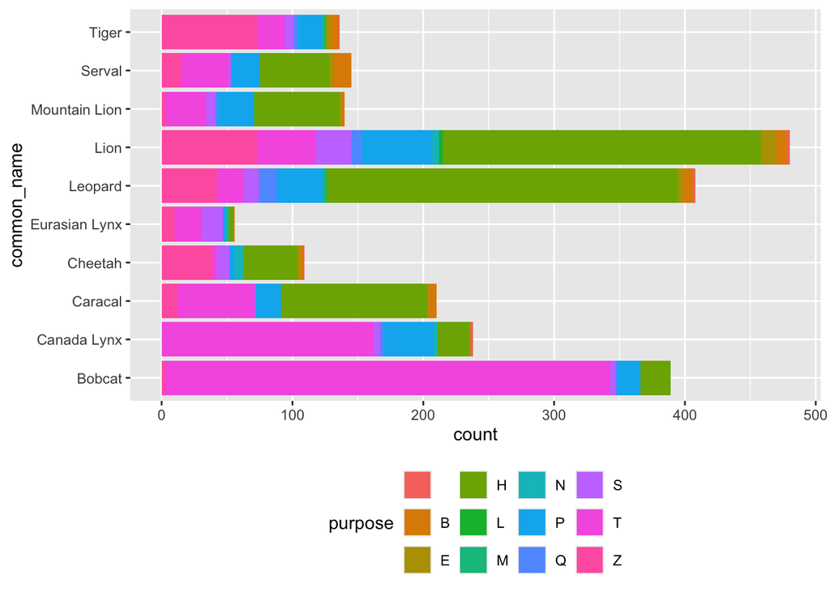

```r
top_cats %>%
  filter(year >= 2022 & year <= 2024) %>%
  group_by(purpose) %>%
  ggplot(aes(x = common_name, fill = purpose)) +
  geom_bar(stat = "count") +
  # scale_fill_manual(
  #   labels = c("Breeding in captivity or artificial propagation",
  #              "Educational",
  #              "Botanical garden",
  #              "Hunting trophy",
  #              "Law enforcement/judicial/forensic",
  #              "Medical (including biomedical research)",
  #              "Reintroduction or introduction into the wild",
  #              "Personal",
  #              "Circus or travelling exhibition",
  #              "Scientific",
  #              "Commercial",
  #              "Zoo")) +
  coord_flip() +
  theme(legend.position = "bottom")
```

Source codes:

- C Animals bred in captivity in accordance with Resolution Conf. 10.16 (Rev.), as well as parts and derivatives thereof, exported under the provisions of Article VII, paragraph 5
- D Appendix-I animals bred in captivity for commercial purposes in operations included in the Secretariat’s Register, in accordance with Resolution Conf. 12.10 (Rev. CoP15), and Appendix-I plants artificially propagated for commercial purposes, as well as parts and derivatives thereof, exported under the provisions of Article VII, paragraph 4, of the Convention
- F Animals born in captivity (F1 or subsequent generations) that do not fulfil the definition of ‘bred in captivity’ in Resolution Conf. 10.16 (Rev.), as well as parts and derivatives thereof
- I Confiscated or seized specimens (may be used with another code)
- O Pre-Convention specimens R Ranched specimens: specimens of animals reared in a controlled environment, taken as eggs or juveniles from the wild, where they would otherwise have had a very low probability of surviving to adulthood
- U Source unknown (must be justified)
- W Specimens taken from the wild

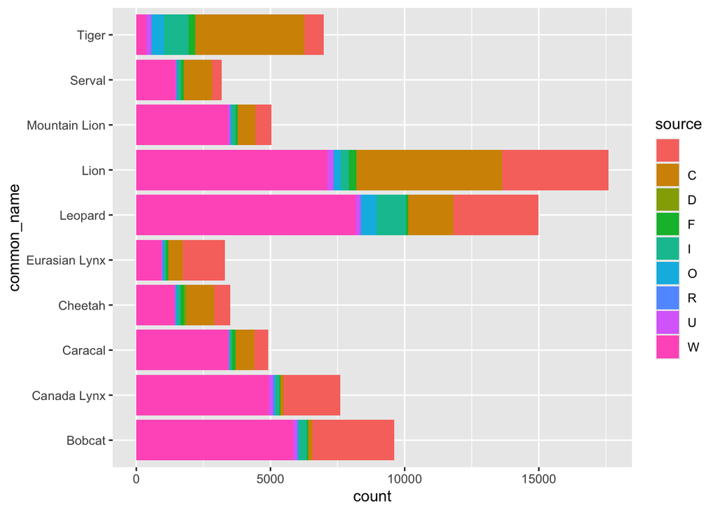

```r
top_cats %>%
  group_by(common_name, source) %>%
  ggplot(aes(x = common_name, fill = source)) +
  geom_bar() +
  coord_flip()
```